Ficha del establecimiento

# Escuela Raul Saéz Saéz

RBD **9734**Lo EspejoEscuela o liceo

252estudiantes matriculadosCorte Agosto 2026

Mujeres44,8%113 est.

Hombres55,2%139 est.

Chilenos/as73,0%184 est.

Extranjeros/as27,0%68 est.

Actualizada al 05-10-2026

💻Ver ficha completaVersión para computador, con mapas y gráficos interactivos. Pesa varios MB: mejor ábrela con wifi.

🏛️Identificación

## Identificación del establecimiento

Los datos de contacto y las características básicas del establecimiento, tal como están registrados en el Ministerio de Educación. **Si algo está mal o falta, escríbenos** y lo corregimos en la próxima actualización.

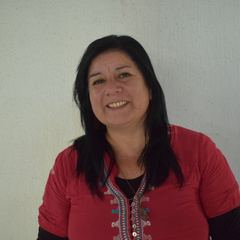

Director o directora

Cecilia Del Pilar Cumican Martinez

**Nombre**

Escuela Raul Saéz Saéz

**RBD**

9734

**Dirección**

Veracruz 5243

**Comuna**

Lo Espejo

**Tipo**

Escuela o liceo

**Estado**

✅En funcionamiento

**Director/a**

Cecilia Del Pilar Cumican Martinez

**Correo**

escuelaraulsaezsaez@slepsantarosa.cl

**Teléfono**

4856823

**Sitio web**

—

**Matrícula**

GRATUITO

**Sostenedor**

El sostenedor corresponde a una persona jurídica

**Orientación**

Orientación religiosa Laica

### Niveles que imparte

✓ 🧸 Educación Parvularia✓ 🎒 Enseñanza Básica Niños

### Vulnerabilidad del alumnado

Índice de vulnerabilidad (IVE)

98,3%

Lo calcula JUNAEB y sirve para asignar programas de apoyo.

0%100%

Este establecimientoPromedio de la comuna 88%

Prioritarios en Básica

87,8%

Estudiantes en 1ª, 2ª o 3ª prioridad.

**Un IVE más alto significa más necesidad de apoyo**, no peor calidad. Se usa para decidir a qué establecimientos llegan primero los programas de alimentación, salud y becas.

### Apoyos profesionales al aprendizaje

✓ 📚 Reforzamiento✓ 🧩 Psicopedagogo/a✓ 🧠 Psicólogo/a🧭 Orientador/a🎓 Orientación vocacional👩‍🏫 Profesor/a de educación especial🤝 Asistente social🗣️ Fonoaudiólogo/a➕ Otro

### Infraestructura y atención a la diversidad

✓ 📚 Biblioteca✓ 🔬 Laboratorio✓ 🌐 Computadores con internet✓ 🏟️ Cancha deportiva🏛️ Sala multiuso💻 Computadores🖥️ Sala de informática📽️ Sala audiovisual🤾 Gimnasio♿ Accesibilidad NEE➕ Otra

✓ 🧠 Discapacidad intelectual✓ 📖 Dificultades de aprendizaje✓ 🗣️ Trastorno específico del lenguaje✓ 🎯 Déficit atencional✓ 📊 Funcionamiento intelectual limítrofe👁️ Discapacidad visual👂 Discapacidad auditiva🦽 Discapacidad motora🧩 Trastorno del espectro autista💬 Trastornos de la comunicación

Las etiquetas con ✓ son las que el establecimiento declaró en el directorio oficial; las grises no están marcadas.

### Jornada Escolar Completa (JEC)

Cursos con jornada completa

6

Cursos sin jornada completa

4

**Ver curso por curso**

| Grado | Cursos | Jornada |
| --- | --- | --- |
| 1° Básico | 1 | — Sin JEC |
| 2° Básico | 1 | — Sin JEC |
| 3° Básico | 1 | ✅ Con JEC |
| 4° Básico | 1 | ✅ Con JEC |
| 5° Básico | 1 | ✅ Con JEC |
| 6° Básico | 1 | ✅ Con JEC |
| 7° Básico | 1 | ✅ Con JEC |
| 8° Básico | 1 | ✅ Con JEC |
| Kínder | 1 | — Sin JEC |
| Pre-kínder | 1 | — Sin JEC |

Con **Jornada Escolar Completa** los estudiantes tienen más horas de clases al día y almuerzan en el establecimiento.

### Idiomas

**Inglés en Enseñanza Básica**

Básico

### Certificación ambiental (SNCAE)

El establecimiento no tiene certificación del Sistema Nacional de Certificación Ambiental de Establecimientos Educacionales (SNCAE).

### Concentración de alumnado prioritario

Concentración 2026

63,2%

▼5,12 pts

Porcentaje de estudiantes prioritarios reconocidos por el Mineduc.

0%100%

Concentración del establecimiento

Concentración 2025

68,3%

Resolución exenta

2026

Observación del Ministerio: **Mantienen ACAP**.

La **concentración de prioritarios** define cuánta Subvención Escolar Preferencial (SEP) recibe el establecimiento. Sobre 60 % da acceso a la asignación por concentración.

### Requisitos para postular

✓ 🎂 Cumplir la edad mínima✓ 📄 Certificado de nacimiento✓ ⚖️ Firmar el reglamento de convivencia📊 Certificado de notas📝 Informe de personalidad🏠 Ficha de protección social🧪 Test de intereses♿ Informe de necesidades educativas✍️ Firmar el proyecto educativo📋 Examen de ingreso👥 Entrevista con apoderados🎲 Sorteo💍 Certificado de matrimonio⛪ Certificado de bautismo⛪ Certificado de matrimonio religioso💰 Pago de postulación➕ Otro

Desde el Sistema de Admisión Escolar, los establecimientos públicos **no pueden seleccionar** por rendimiento ni por antecedentes socioeconómicos. Estos son los antecedentes administrativos que el establecimiento declara pedir.

**Equipo del SLEP que acompaña al establecimiento**

**Asesor/a territorial**

TAMARA ROA CARES

**Correo UTP**

utp.escuelaraulsaezsaez@slepsantarosa.cl

**Correo Inspectoría**

—

🏫Matrícula

## Matrícula y asistencia

Cuántos estudiantes tiene el establecimiento, quiénes son y cuántos días van efectivamente a clases. **La asistencia es el porcentaje de días que los estudiantes asistieron** sobre los días en que estuvieron matriculados.

Matrícula · Agosto 2026

252

▼0,4%

Variación desde el primer mes del año escolar.

1141.024

Este establecimientoPromedio del SLEP 333

Asistencia promedio

84,0%

Días asistidos sobre días matriculados.

83,0%97,6%

Este añoPromedio de años anteriores 89,0%

Cursos

10

Niveles

2

Matrícula regular

252

Estudiantes en la modalidad regular del establecimiento.

Matrícula no regular

0

Modalidades de adultos, reingreso o validación de estudios.

Matrícula mes a mes · 2026

Cuántos estudiantes había registrados al cierre de cada mes.

Asistencia mes a mes · 2026

Porcentaje de días asistidos sobre los días en que el estudiante estuvo matriculado.

Matrícula año a año

Matrícula del último mes de cada año escolar.

### Quiénes estudian acá

Por género

Hombres · 139Mujeres · 113

Por origen

Chilenos/as · 184Extranjeros/as · 68Nacionalizados/as · 0

Nacionalidades presentes

Número de estudiantes por país de nacimiento declarado.

🇨🇱 Chilena165

🇻🇪 Venezolana31

🌐 Otra29

❔ Sin información8

🇭🇹 Haitiana7

🇨🇴 Colombiana3

Otros8

Pueblos originarios

Estudiantes que declaran pertenecer a un pueblo originario.

🌿 Mapuche8

🌐 Otra etnia1

### Por nivel de enseñanza

Matrícula por nivel

🧸 Educación Parvularia35

🎒 Enseñanza Básica Niños217

Asistencia por nivel

La escala va de 0 % a 100 %.

🧸 Educación Parvularia77,6%

🎒 Enseñanza Básica Niños85,1%

### Asistencia por grupo

Asistencia por género

Promedio ponderado por el número de estudiantes de cada grupo.

Hombres83,4%

Mujeres84,7%

Asistencia por origen

Chilenos/as82,5%

Extranjeros/as88,0%

Asistencia por nacionalidad

Solo los seis grupos con más estudiantes.

🇨🇱 Chilena82,6%

🇻🇪 Venezolana84,6%

🌐 Otra87,1%

❔ Sin información82,7%

🇭🇹 Haitiana95,9%

🇨🇴 Colombiana88,9%

Asistencia por pueblo originario

🌿 Mapuche84,4%

🌐 Otra etnia0,0%

**Ver el detalle curso por curso (10 cursos)**

| Curso | Matrícula | Asistencia % |
| --- | --- | --- |
| Pre-kínder A | 20 | 77,4 |
| Kínder A | 15 | 77,8 |
| 1° Básico A | 22 | 84,9 |
| 2° Básico A | 33 | 79,5 |
| 3° Básico A | 31 | 89,9 |
| 4° Básico A | 27 | 84,1 |
| 5° Básico A | 28 | 83,7 |
| 6° Básico A | 27 | 81,8 |
| 7° Básico A | 26 | 89,7 |
| 8° Básico A | 23 | 87,9 |

**Ver la matrícula año a año, con su variación**

| Periodo | Matrícula | Variación | Cambio |
| --- | --- | --- | --- |
| 2026 | 252 | −18,0 | −6,7% |
| 2025 | 270 | −16,0 | −5,6% |
| 2024 | 286 | +21,0 | +7,9% |
| 2023 | 265 | −10,0 | −3,6% |
| 2022 | 275 | +60,0 | +27,9% |
| 2019 | 215 | +28,0 | +15,0% |
| 2018 | 187 | +20,0 | +12,0% |
| 2017 | 167 | −24,0 | −12,6% |
| 2016 | 191 | — | — |

**Ver la asistencia año a año, con su variación**

| Periodo | Asistencia | Variación | Cambio |
| --- | --- | --- | --- |
| 2026 | 84,0% | −1,1 pts | −1,3% |
| 2025 | 85,1% | −1,7 pts | −2,0% |
| 2024 | 86,8% | +1,3 pts | +1,5% |
| 2023 | 85,5% | −0,8 pts | −0,9% |
| 2022 | 86,3% | −6,0 pts | −6,5% |
| 2019 | 92,3% | −4,3 pts | −4,5% |
| 2018 | 96,6% | +5,5 pts | +6,0% |
| 2017 | 91,1% | +2,9 pts | +3,3% |
| 2016 | 88,2% | — | — |

La matrícula se cuenta al cierre de cada mes, así que los cambios durante el año reflejan traslados y retiros. Corte usado: **Agosto 2026**.

🤝Vida escolar

## Vida escolar y comunidad

Qué actividades ofrece el establecimiento fuera de las clases, cómo se organiza con las familias y quiénes representan a la comunidad. **Las etiquetas con ✓ son las que el establecimiento declaró** en el directorio oficial del Ministerio; las grises no están marcadas.

### Talleres y actividades para estudiantes

✓ 🤝 Convivencia✓ 🚫 Prevención drogas🧭 Orientación❤️ Educación sexual🌱 Medio ambiente🌟 Vida sana🫂 Acción social✝️ Pastoral➕ Otra

Actividades de formación: orientación, convivencia, prevención y vida sana.

✓ 🎵 Música🎭 Teatro📚 Literatura✂️ Manualidades🩰 Danza o ballet🎨 Artes plásticas💻 Taller TIC🎓 Preuniversitario➕ Otro

Talleres de arte, cultura y tecnología fuera del horario de clases.

✓ ⚽ Fútbol✓ 🥅 Baby fútbol✓ 🏀 Básquetbol🏃 Atletismo🏐 Vóleibol🏊 Natación🤸 Gimnasia🎾 Tenis🏓 Tenis de mesa♟️ Ajedrez➕ Otro

Disciplinas deportivas que ofrece el establecimiento.

### Trabajo con las familias

El establecimiento no registra ninguna de estas actividades en el directorio oficial.

✓ 📒 Libreta de comunicaciones✓ 🌐 Web y redes sociales✓ 🗣️ Consejo escolar✓ 📄 Reuniones generales✓ 👥 Entrevistas individuales➕ Otro

Por dónde el establecimiento se comunica con apoderados y apoderadas.

### Organizaciones de la comunidad

**Centro de Padres**

Constituido

**Personalidad jurídica**

Vencida

**Última elección de directiva**

**Centro de Estudiantes**

—

**Representante del sostenedor en el Consejo Escolar**

Bruno Cortés González

**Acompañamiento del Consejo Escolar**

Osman Yeomans Jiménez

Para contactar al centro de padres o al centro de estudiantes, escribe al establecimiento: sus datos están más arriba.

El **Consejo Escolar** es la instancia donde se juntan dirección, docentes, asistentes, apoderados y estudiantes para conversar sobre la marcha del establecimiento.

### Normativa y conectividad

**Uso de uniforme**

Uniforme propio del establecimiento

**Tipo de conexión**

Fibra óptica

**Velocidad de internet**

Sin información

🧭Gestión

## Instrumentos de gestión: PEI y PME

El **PEI** dice quién quiere ser el establecimiento: su misión, su visión y sus sellos. El **PME** dice qué va a hacer este año para lograrlo, con responsables y presupuesto. Son los dos documentos que ordenan el trabajo.

### Proyecto Educativo Institucional (PEI)

**Misión**

La escuela RAÚL SAEZ SÁEZ, es una institución que forma personas integrales con énfasis en lo académico y valórico. Fomenta el compromiso de toda la comunidad educativa, generando espacios de comunicación, innovadores e interactivos, promoviendo de modo permanente las prácticas educativas de calidad.

**Visión**

La Escuela RAÚL SÁEZ SÁEZ, ofrece una educación que promueve prácticas educativas de calidad efectiva, responsables, basadas en el marco de un proyecto que incluye una educación centrada en la formación integral , académica y valórica

### Énfasis declarados, en orden de prioridad

**1º**

Desarrollo integral

**2º**

Inclusivo

**3º**

Excelencia académica

### Documentos oficiales

[📘Proyecto Educativo](https://wwwfs.mineduc.cl/Archivos/infoescuelas/documentos/9734/ProyectoEducativo9734.pdf)[⚖️Reglamento de Convivencia](https://wwwfs.mineduc.cl/Archivos/infoescuelas/documentos/9734/ReglamentodeConvivencia9734.pdf)[📊Reglamento de Evaluación](https://wwwfs.mineduc.cl/Archivos/infoescuelas/documentos/9734/ReglamentoDeEvaluacion9734.pdf)

### Plan de Mejoramiento Educativo (PME)

Acciones comprometidas

21

Inversión total del plan

$ 145.432.039

Dimensiones cubiertas

4

Acciones por dimensión

Las cuatro dimensiones del PME: gestión pedagógica, liderazgo, convivencia y recursos.

Gestión Pedagógica6

Convivencia Escolar5

Gestión de Recursos5

Liderazgo5

Quién lidera las acciones

Los cinco responsables con más acciones a cargo.

Jefe técnico6

Encargado de convivencia5

Equipo de gestión4

Sostenedor4

Director2

De dónde sale el financiamiento

Monto comprometido por fuente de recursos.

sep$ 143.589.948

pie$ 1.842.091

**Ver las 21 acciones del plan**

| Acción | Dimensión | Responsable | Monto |
| --- | --- | --- | --- |
| Servicio de Plataforma Educativa | Gestión Pedagógica | Jefe técnico | $ 1.842.091 |
| Trabajo colaborativo para el desarrollo profesional docente. | Gestión Pedagógica | Jefe técnico | $ 0 |
| Servicio de Impresión para el Apoyo Pedagógico | Gestión Pedagógica | Jefe técnico | $ 2.417.989 |
| implementación Plan de Prevención de la Repitencia | Gestión Pedagógica | Jefe técnico | $ 2.500.000 |
| Elaboración plan de intervención terapéutico integral | Gestión Pedagógica | Jefe técnico | $ 2.500.000 |
| Salidas pedagogicas | Gestión Pedagógica | Jefe técnico | $ 4.000.000 |
| Contratación de Profesionales para el Apoyo en la Gestión Educativa (10% Administración Central) | Liderazgo | Sostenedor | $ 10.935.154 |
| Promoción sellos institucionales a través Actividades emblemáticas | Liderazgo | Equipo de gestión | $ 0 |
| Acompañamiento a Equipos de trabajo | Liderazgo | Equipo de gestión | $ 0 |
| Monitoreo interno del desempeño del establecimiento | Liderazgo | Equipo de gestión | $ 0 |
| Ajustar , ajustar o reformular PEI | Liderazgo | Equipo de gestión | $ 0 |
| Educar en la resolución pacífica de conflictos y reparación en los y las miembros de la comunidad e | Convivencia Escolar | Encargado de convivencia | $ 0 |
| Recreos Preventivos | Convivencia Escolar | Encargado de convivencia | $ 0 |
| Actividades interculturales | Convivencia Escolar | Encargado de convivencia | $ 459.089 |
| Construcción de una sana Convivencia | Convivencia Escolar | Encargado de convivencia | $ 0 |
| Escuela Divertida | Convivencia Escolar | Encargado de convivencia | $ 0 |
| Contratación de Docentes y/o Asistentes de la Educación para Apoyo Pedagógico | Gestión de Recursos | Director | $ 114.829.113 |
| Compra de Material Escolar para el Apoyo al Aprendizaje | Gestión de Recursos | Director | $ 1.385.946 |
| Compra de mobiliario para biblioteca CRA | Gestión de Recursos | Sostenedor | $ 1.857.877 |
| compra de equipos computacionales y periféricos y | Gestión de Recursos | Sostenedor | $ 796.977 |
| Compra de impresoras maquinas y equipos | Gestión de Recursos | Sostenedor | $ 1.907.803 |

**Ver plazos y estado de ejecución de cada acción**

| Acción | Inicio | Término | Nivel de ejecución |
| --- | --- | --- | --- |
| Servicio de Plataforma Educativa | 03/6/2025 | 23/12/2025 | Implementado parcialmente (25 a 49%) |
| Trabajo colaborativo para el desarrollo profesional docente. | 01/4/2025 | 31/12/2025 | Implementado de manera adecuada (50% a 74%) |
| Servicio de Impresión para el Apoyo Pedagógico | 03/6/2025 | 23/12/2025 | Implementado de manera adecuada (50% a 74%) |
| implementación Plan de Prevención de la Repitencia | 01/4/2025 | 30/11/2025 | Implementado de manera adecuada (50% a 74%) |
| Elaboración plan de intervención terapéutico integral | 01/4/2025 | 31/12/2025 | Implementación avanzada (75% a 99%) |
| Salidas pedagogicas | 01/8/2025 | 28/11/2025 | Aún no se encuentra evaluado |
| Contratación de Profesionales para el Apoyo en la Gestión Educativa (10% Administración Central) | 03/3/2025 | 23/12/2025 | Aún no se encuentra evaluado |
| Promoción sellos institucionales a través Actividades emblemáticas | 21/4/2025 | 29/11/2025 | Aún no se encuentra evaluado |
| Acompañamiento a Equipos de trabajo | 01/4/2025 | 31/12/2025 | Aún no se encuentra evaluado |
| Monitoreo interno del desempeño del establecimiento | 01/4/2025 | 29/12/2025 | Aún no se encuentra evaluado |
| Ajustar , ajustar o reformular PEI | 01/5/2025 | 31/12/2025 | Aún no se encuentra evaluado |
| Educar en la resolución pacífica de conflictos y reparación en los y las miembros de la comunidad e | 31/3/2025 | 25/12/2025 | Implementado parcialmente (25 a 49%) |
| Recreos Preventivos | 08/7/2025 | 28/11/2025 | Implementado inicialmente (1% a 24%) |
| Actividades interculturales | 10/7/2025 | 30/11/2025 | Implementado parcialmente (25 a 49%) |
| Construcción de una sana Convivencia | 08/7/2025 | 24/12/2025 | Implementado parcialmente (25 a 49%) |
| Escuela Divertida | 01/4/2025 | 30/11/2025 | Implementado parcialmente (25 a 49%) |
| Contratación de Docentes y/o Asistentes de la Educación para Apoyo Pedagógico | 31/3/2025 | 23/12/2025 | Aún no se encuentra evaluado |
| Compra de Material Escolar para el Apoyo al Aprendizaje | 04/6/2025 | 24/12/2025 | Aún no se encuentra evaluado |
| Compra de mobiliario para biblioteca CRA | 07/7/2025 | 28/11/2025 | Aún no se encuentra evaluado |
| compra de equipos computacionales y periféricos y | 01/4/2025 | 29/11/2025 | Aún no se encuentra evaluado |
| Compra de impresoras maquinas y equipos | 07/6/2025 | 28/11/2025 | Aún no se encuentra evaluado |

**Ver estrategia, programa y medios de verificación**

| Acción | Estrategia | Programa asociado | Medios de verificación |
| --- | --- | --- | --- |
| Servicio de Plataforma Educativa | Consolidar acciones que permitan una cultura colaborativa sistematizando los procesos de acompañamiento y articulación curricular, de prácticas de innovación exitosas entre los y las docentes y profes… | SEP | -? Reportes -? Informe de notas -? Informe Uso Plataforma |
| Trabajo colaborativo para el desarrollo profesional docente. | Consolidar acciones que permitan una cultura colaborativa sistematizando los procesos de acompañamiento y articulación curricular, de prácticas de innovación exitosas entre los y las docentes y profes… | Reforzamiento educativo | -Planificación y monitoreo de acciones -cronograma de de reuniones por nivel -actas de reuniones |
| Servicio de Impresión para el Apoyo Pedagógico | Consolidar acciones que permitan una cultura colaborativa sistematizando los procesos de acompañamiento y articulación curricular, de prácticas de innovación exitosas entre los y las docentes y profes… | SEP | -? Contrato suministro |
| implementación Plan de Prevención de la Repitencia | Consolidar acciones que permitan una cultura colaborativa sistematizando los procesos de acompañamiento y articulación curricular, de prácticas de innovación exitosas entre los y las docentes y profes… | Reforzamiento educativo | -diagnóstico individual de estudiantes ingresados al plan -Plan de intervención -informes de avances semestrales -lista de estudiantes |
| Elaboración plan de intervención terapéutico integral | Consolidar acciones que permitan una cultura colaborativa sistematizando los procesos de acompañamiento y articulación curricular, de prácticas de innovación exitosas entre los y las docentes y profes… | PIE | -Plan de Intervención -listado de estudiantes -horarios de atención -informes de avances |
| Salidas pedagogicas | Consolidar acciones que permitan una cultura colaborativa sistematizando los procesos de acompañamiento y articulación curricular, de prácticas de innovación exitosas entre los y las docentes y profes… | Ninguno | -protocolos de salidas pedagógicas -planificación de salidas pedagógicas -cronograma de salidas |
| Contratación de Profesionales para el Apoyo en la Gestión Educativa (10% Administración Central) | Consolidad instrumentos de promoción que permitan visualizar el sentido de pertenencia de la comunidad escolar, y la medición de impacto de las acciones del PME y PEI. Facilitando el desarrollo de una… | SEP | -Informes de avance y ejecución -Convenios de prestación de servicios |
| Promoción sellos institucionales a través Actividades emblemáticas | Consolidad instrumentos de promoción que permitan visualizar el sentido de pertenencia de la comunidad escolar, y la medición de impacto de las acciones del PME y PEI. Facilitando el desarrollo de una… | Ninguno | -invitaciones y promoción medios de comunicación -planificación de las actividades -lista de participantes -cronograma de actividades |
| Acompañamiento a Equipos de trabajo | Consolidad instrumentos de promoción que permitan visualizar el sentido de pertenencia de la comunidad escolar, y la medición de impacto de las acciones del PME y PEI. Facilitando el desarrollo de una… | SEP | -actas de reuniones y acuerdos -cronograma de actividades |
| Monitoreo interno del desempeño del establecimiento | Consolidad instrumentos de promoción que permitan visualizar el sentido de pertenencia de la comunidad escolar, y la medición de impacto de las acciones del PME y PEI. Facilitando el desarrollo de una… | SEP | -informe de monitoreo -actas de jornadas de reflexión |
| Ajustar , ajustar o reformular PEI | Consolidad instrumentos de promoción que permitan visualizar el sentido de pertenencia de la comunidad escolar, y la medición de impacto de las acciones del PME y PEI. Facilitando el desarrollo de una… | Ninguno | -calendario de encuentros -listas de participantes por estamento -actas de acuerdos |
| Educar en la resolución pacífica de conflictos y reparación en los y las miembros de la comunidad e | Establecer procesos de articulación con acciones que se vinculan con la orientación y acompañamiento individual o grupal de los/las estudiantes, propiciando el desarrollo integral de la comunidad esco… | Ninguno | -Informe de monitoreo de derivaciones, judicializaciones y de activación protocolo suicidio -Resumen de acciones de convivencia -Informe de acciones sobre acuerdos de reuniones integrales |
| Recreos Preventivos | Establecer procesos de articulación con acciones que se vinculan con la orientación y acompañamiento individual o grupal de los/las estudiantes, propiciando el desarrollo integral de la comunidad esco… | Ninguno | -Planificaciones de las actividades -Evaluación virtual de la actividad |
| Actividades interculturales | Establecer procesos de articulación con acciones que se vinculan con la orientación y acompañamiento individual o grupal de los/las estudiantes, propiciando el desarrollo integral de la comunidad esco… | Ninguno | -Planificación de las actividades -Registro audiovisual |
| Construcción de una sana Convivencia | Establecer procesos de articulación con acciones que se vinculan con la orientación y acompañamiento individual o grupal de los/las estudiantes, propiciando el desarrollo integral de la comunidad esco… | Ninguno | -Planificación de las actividades -Registro audiovisual -Informe cuantitativo comparando ambos semestres |
| Escuela Divertida | Establecer procesos de articulación con acciones que se vinculan con la orientación y acompañamiento individual o grupal de los/las estudiantes, propiciando el desarrollo integral de la | Ninguno | -Nómina de asistencia -Registro audiovisual -Planificación de las actividades |
| Contratación de Docentes y/o Asistentes de la Educación para Apoyo Pedagógico | Reestructurar un plan de distribución de los gastos en todas las dimensiones y requerimientos necesarios en la escuela. | SEP | -Registro de asistencia -Plan de trabajo |
| Compra de Material Escolar para el Apoyo al Aprendizaje | Reestructurar un plan de distribución de los gastos en todas las dimensiones y requerimientos necesarios en la escuela. | SEP | -? Solicitud de compras |
| Compra de mobiliario para biblioteca CRA | Reestructurar un plan de distribución de los gastos en todas las dimensiones y requerimientos | SEP | -Guias de despacho -solicitud de compras |
| compra de equipos computacionales y periféricos y | Reestructurar un plan de distribución de los gastos en todas las dimensiones y requerimientos necesarios en la escuela. | SEP | -solicitud de compras -guías de despacho y entrega |
| Compra de impresoras maquinas y equipos | Reestructurar un plan de distribución de los gastos en todas las dimensiones y requerimientos necesarios en la escuela. | SEP | -guía de despacho o entrega -solicitud de compra -orden de compra |

**Ver la descripción completa y la justificación de cada acción**

[output not shown]

🏆SNED

## SNED · Sistema Nacional de Evaluación del Desempeño

El SNED evalúa cada dos años el desempeño de los establecimientos municipales y particulares subvencionados. Mira **seis factores**: efectividad, superación, igualdad de oportunidades, iniciativa, integración y mejoramiento.

⚪No seleccionado

Índice SNED del establecimiento

Va de 0 a 100 y resume los seis factores que evalúa el sistema.

Los seis factores, uno por uno

Cada factor va de 0 a 100. Los de arriba pesan más en el índice final.

Efectividad41,2%

Superación52,3%

Igualdad de oportunidades92,3%

Iniciativa91,5%

Integración77,4%

Mejoramiento99,7%

**¿Cuánto pesa cada factor?**

| Factor | Puntaje | Peso en el índice (%) |
| --- | --- | --- |
| Efectividad | 41,2 | 37 |
| Superación | 52,3 | 28 |
| Igualdad de oportunidades | 92,3 | 22 |
| Iniciativa | 91,5 | 6 |
| Integración | 77,4 | 5 |
| Mejoramiento | 99,7 | 2 |

El SNED premia con un bono a los equipos de los establecimientos con mejor desempeño dentro de un grupo de escuelas parecidas. **No es una nota**: compara con establecimientos de condiciones similares, no con todo Chile.

💼Ocupación

## Ocupación de cupos

Cuántos de los cupos que el establecimiento ofreció están efectivamente ocupados. **Se calcula dividiendo la matrícula actual por los cupos declarados** en el Sistema de Admisión Escolar (SAE).

⚠️Con cupos disponibles

Ocupación de los cupos

La marca gris señala el 100 %: por sobre esa línea hay más estudiantes que cupos declarados.

Cupos declarados (SAE)

324

Matrícula al corte

252

Agosto 2026

Cupos libres

72

Cupos que quedan sin usar.

Vacantes en el curso de ingreso

25

**Ver los cupos declarados por grado**

| Grado | Cursos | Cupos |
| --- | --- | --- |
| 1° Básico | 1 | 33 |
| 2° Básico | 1 | 33 |
| 3° Básico | 1 | 33 |
| 4° Básico | 1 | 33 |
| 5° Básico | 1 | 33 |
| 6° Básico | 1 | 33 |
| 7° Básico | 1 | 33 |
| 8° Básico | 1 | 33 |
| Kínder | 1 | 30 |
| Pre-kínder | 1 | 30 |

La ocupación compara la **matrícula efectiva** con los **cupos que el establecimiento declaró** en el Sistema de Admisión Escolar. Una ocupación baja no siempre es mala: puede ser espacio para crecer.

♿PIE

## Programa de Integración Escolar (PIE)

Cuántos estudiantes reciben apoyos del PIE y qué tipo de apoyo necesitan. Las **necesidades permanentes** acompañan toda la trayectoria escolar; las **transitorias** requieren apoyo por un tiempo determinado.

Estudiantes en PIE · 2026

49

Se cuenta cada estudiante una sola vez.

0,0%40,0%

Porcentaje de la matrícula

NEE permanentes

13

Acompañan toda la trayectoria escolar.

NEE transitorias

36

Requieren apoyo por un tiempo acotado.

Sobre la matrícula

19,4%

Tipo de necesidad educativa

NEE permanentes · 13NEE transitorias · 36

Por género

Hombres · 28Mujeres · 21

Diagnósticos más frecuentes

Los ocho diagnósticos con más estudiantes.

Trastorno del Lenguaje24

Funcionamiento Intelectual Limítrofe10

Discapacidad Intelectual9

Trastorno del Espectro Autista3

Dificultades Específicas del Aprendizaje1

Hipoacusia Severa1

Trastorno de Déficit Atencional1

En qué cursos están

3° Básico7

1° Básico6

2° Básico6

4° Básico6

5° Básico6

7° Básico6

8° Básico5

Kínder4

6° Básico3

Por nivel de enseñanza

Enseñanza Básica Niños45

Educación Parvularia4

**Ver el cruce entre género y tipo de necesidad**

| Genero | PERMANENTE | TRANSITORIO |
| --- | --- | --- |
| Femenino | 4 | 17 |
| Masculino | 9 | 19 |

**Ver el cruce entre género y los diagnósticos más frecuentes**

| Genero | Dificultades Específicas del Aprendizaje | Discapacidad Intelectual | Funcionamiento Intelectual Limítrofe | Trastorno del Lenguaje | Trastorno del Espectro Autista |
| --- | --- | --- | --- | --- | --- |
| Femenino | 1 | 4 | 8 | 8 | 0 |
| Masculino | 0 | 5 | 2 | 16 | 3 |

**Ver todos los diagnósticos registrados**

| Diagnóstico | Tipo de NEE | Estudiantes |
| --- | --- | --- |
| Trastorno del Lenguaje | TRANSITORIO | 24 |
| Funcionamiento Intelectual Limítrofe | TRANSITORIO | 10 |
| Discapacidad Intelectual | PERMANENTE | 9 |
| Trastorno del Espectro Autista | PERMANENTE | 3 |
| Dificultades Específicas del Aprendizaje | TRANSITORIO | 1 |
| Hipoacusia Severa | PERMANENTE | 1 |
| Trastorno de Déficit Atencional | TRANSITORIO | 1 |

### Postulaciones al programa, por período

Estudiantes por año y período

El período **Regular** es la postulación anual; **Extraordinario** y **Excepcionalidad** son cupos que se abren después.

2026 · Excepcionalidad10

2026 · Regular70

2025 · Excepcionalidad10

2025 · Regular68

2024 · Regular + Excepcionalidad76

**Ver el detalle por año, período y tipo de necesidad**

| Año | Período | Tipo de NEE | Estudiantes |
| --- | --- | --- | --- |
| 2.026 | Excepcionalidad | PERMANENTE | 10 |
| 2.026 | Regular | PERMANENTE | 20 |
| 2.026 | Regular | TRANSITORIO | 50 |
| 2.025 | Excepcionalidad | PERMANENTE | 10 |
| 2.025 | Regular | PERMANENTE | 18 |
| 2.025 | Regular | TRANSITORIO | 50 |
| 2.024 | Regular + Excepcionalidad | PERMANENTE | 27 |
| 2.024 | Regular + Excepcionalidad | TRANSITORIO | 49 |

Evolución del programa

Fuente: base territorial del Área de Inclusión Educativa del SLEP.

El PIE entrega apoyos dentro del aula a estudiantes con necesidades educativas especiales. **Estar en PIE no es un diagnóstico permanente**: muchas necesidades son transitorias y se superan con apoyo.

🔄Retiros

## Retiros y movilidad estudiantil

Cuántos estudiantes se retiraron del establecimiento, cuándo y hacia dónde. **Lo importante es saber si volvieron a matricularse en otra parte**: quienes no lo hicieron son los casos que hay que buscar.

Retiros en 2026

24

Equivale al 9,5% de la matrícula actual.

Ya están en otro establecimiento

12

Se confirmó matrícula posterior.

Sin matrícula vigente

2

Requieren seguimiento: pueden estar fuera del sistema.

Pendiente en SIGE

10

Todavía sin información de destino.

En qué meses se producen

Tipo de movimiento

Cambio a otro EE fuera del SLEP16

Cambio a otro EE pertenenciente al SLEP5

Sin matrícula3

A qué establecimientos se van

Los seis destinos más frecuentes.

Complejo Educ.part.monsenor Luis A.perez4

Escuela Bas. Rosa Elvira Matte De Prieto3

Escuela Millahue3

Sin destino informado3

Colegio Alonso De Ercilla2

Escuela Blue Star College2

Desde qué cursos

4° Básico5

6° Básico5

Pre-kínder4

8° Básico3

5° Básico2

Kínder2

1° Básico1

3° Básico1

7° Básico1

Qué tipo de establecimiento eligieron

Dependencia del establecimiento de destino.

Particular Subvencionado12

Mismo Slep5

Otro Slep4

Sin Matrícula3

A qué comunas se fueron

Lo Espejo10

Pedro Aguirre Cerda4

Cerro Navia3

Sin información3

San Felipe2

Puente Alto1

San Bernardo1

**Ver todos los destinos, uno por uno**

| Establecimiento | Comuna | Dependencia | Estudiantes |
| --- | --- | --- | --- |
| Complejo Educ.part.monsenor Luis A.perez | Pedro Aguirre Cerda | Particular Subvencionado | 4 |
| Escuela Bas. Rosa Elvira Matte De Prieto | Lo Espejo | Particular Subvencionado | 3 |
| Escuela Millahue | Cerro Navia | Otro Slep | 3 |
| Sin destino informado | — | Sin Matrícula | 3 |
| Colegio Alonso De Ercilla | San Felipe | Particular Subvencionado | 2 |
| Escuela Blue Star College | Lo Espejo | Mismo Slep | 2 |
| Escuela Básica Bernardo O´Higgins | Lo Espejo | Mismo Slep | 2 |
| Colegio Particular San Mateo | Puente Alto | Particular Subvencionado | 1 |
| Colegio Poliv. Saint Trinity College | Lo Espejo | Particular Subvencionado | 1 |
| Colegio San Lucas De Lo Espejo | Lo Espejo | Particular Subvencionado | 1 |
| Escuela Básica Acapulco | Lo Espejo | Mismo Slep | 1 |
| Liceo Clara Solovera | San Bernardo | Otro Slep | 1 |

Un retiro no siempre es una pérdida: muchas veces la familia se cambia de comuna. Lo que sí requiere seguimiento son los estudiantes **sin matrícula vigente** en ningún otro establecimiento.

📚Resultados

## Resultados educativos

Cómo les fue a los estudiantes en sus notas y cuántos pasaron de curso. El **promedio general** va de 1,0 a 7,0 y la **tasa de aprobación** es el porcentaje de estudiantes que fue promovido al curso siguiente.

Promedio general · 2025

6,0de 7,0

Promedio de todas las notas finales, ponderado por el tamaño de cada curso.

5,46,3

Este establecimientoPromedio del SLEP 5,9

Tasa de aprobación

100,0%

Promovidos sobre el total de estudiantes con situación final.

50%100%

Este establecimientoPromedio del SLEP 97%

Estudiantes promovidos

231

Estudiantes reprobados

0

Cómo terminó el año 2025

Situación final de cada estudiante al cierre del año escolar.

Promovidos · 231Retirados · 3Trasladados · 23

Promedio general año a año

Escala de notas de 1,0 a 7,0.

Tasa de aprobación año a año

Porcentaje de estudiantes promovidos.

**Ver el detalle por curso (8 grados)**

| Grado | Estudiantes | Promedio | Aprobación % |
| --- | --- | --- | --- |
| 1° Básico | 32 | 6,1 | 100 |
| 2° Básico | 32 | 6,2 | 100 |
| 3° Básico | 28 | 6,5 | 100 |
| 4° Básico | 35 | 6,1 | 100 |
| 5° Básico | 34 | 5,9 | 100 |
| 6° Básico | 33 | 6 | 100 |
| 7° Básico | 30 | 5,9 | 100 |
| 8° Básico | 33 | 5,9 | 100 |

### Aprobación por grupo

Tasa de aprobación por género

Masculino100,0%

Femenino100,0%

Tasa de aprobación por origen

Chileno100,0%

Extranjero100,0%

**Ver el promedio de notas por grupo**

| Género | Estudiantes | Promedio | Aprobación % |
| --- | --- | --- | --- |
| Masculino | 142 | 6 | 100 |
| Femenino | 115 | 6,1 | 100 |

| Origen | Estudiantes | Promedio | Aprobación % |
| --- | --- | --- | --- |
| Chileno | 172 | 6,1 | 100 |
| Extranjero | 85 | 6 | 100 |

### Cómo terminó cada año

Año 2025

Promovidos · 231Reprobados · 0Retirados · 3Trasladados · 23

Año 2024

Año 2023

Año 2022

**Ver la tabla de situación final año a año**

| Año | Promovidos | Reprobados | Retirados | Trasladados |
| --- | --- | --- | --- | --- |
| 2.025 | 231 | 0 | 3 | 23 |
| 2.024 | 234 | 4 | 17 | 27 |
| 2.023 | 214 | 3 | 16 | 28 |
| 2.022 | 210 | 6 | 9 | 34 |

**Ver el promedio y la aprobación año a año**

| Periodo | Promedio | Variación | Cambio |
| --- | --- | --- | --- |
| 2025 | 6,0 | −0,1 | −1,1% |
| 2024 | 6,1 | +0,2 | +2,7% |
| 2023 | 6,0 | +0,1 | +1,2% |
| 2022 | 5,9 | — | — |

| Periodo | Aprobación | Variación | Cambio |
| --- | --- | --- | --- |
| 2025 | 100,0% | +1,7 pts | +1,7% |
| 2024 | 98,3% | −0,3 pts | −0,3% |
| 2023 | 98,6% | +1,4 pts | +1,4% |
| 2022 | 97,2% | — | — |

La tasa de aprobación deja fuera a quienes se retiraron o se trasladaron durante el año: **solo considera a quienes terminaron el año en el establecimiento**.

📐SIMCE

## SIMCE

El SIMCE es la prueba que aplica la Agencia de Calidad para saber cuánto aprendieron los estudiantes en Lectura y Matemática. Además del puntaje, muestra **cuántos estudiantes quedaron en cada nivel de aprendizaje**: Insuficiente, Elemental o Adecuado.

### Categoría de desempeño

⚠️Básica 2019: MEDIO-BAJO

La categoría de desempeño la asigna la Agencia de Calidad y considera resultados **y** el contexto social del establecimiento. Va de Alto a Insuficiente.

### Resultados por curso

Última medición disponible: **2025**.

Lectura

258pts

▲14 pts

Variación respecto de la medición anterior.

191263

Última mediciónPromedio de años anteriores 230

Matemática

244pts

▲10 pts

Variación respecto de la medición anterior.

197251

Última mediciónPromedio de años anteriores 223

### ¿El cambio es real?

•Lectura ■Sin cambio significativo•Matemática ■Sin cambio significativo

La Agencia de Calidad indica si la diferencia con la medición anterior es **estadísticamente significativa**. Si no lo es, el cambio puede deberse al azar.

Niveles de aprendizaje · Lectura

Porcentaje de estudiantes en cada nivel de logro.

Insuficiente · 37,5%Elemental · 37,5%Adecuado · 25,0%

Niveles de aprendizaje · Matemática

Porcentaje de estudiantes en cada nivel de logro.

Insuficiente · 56,0%Elemental · 40,0%Adecuado · 4,0%

Evolución de los puntajes

Puntaje promedio del establecimiento en cada medición.

LecturaMatemática

**Comparar con establecimientos de condiciones parecidas**

| Prueba | Este establecimiento | Grupo de comparación | Diferencia |
| --- | --- | --- | --- |
| Lectura | 258 | 259 | −1 pts |
| Matemática | 244 | 243 | +1 pts |

El grupo de comparación reúne establecimientos con estudiantes de condiciones socioeconómicas similares.

**Ver todos los puntajes históricos**

| Prueba | Año | Puntaje | Estudiantes |
| --- | --- | --- | --- |
| Lectura | 2016 | 232 | 12 |
| Lectura | 2017 | 196 | 14 |
| Lectura | 2018 | 255 | 9 |
| Lectura | 2022 | 214 | 20 |
| Lectura | 2023 | 239 | 26 |
| Lectura | 2024 | 244 | 28 |
| Lectura | 2025 | 258 | — |
| Matemática | 2016 | 223 | 10 |
| Matemática | 2017 | 201 | 13 |
| Matemática | 2018 | 247 | 9 |
| Matemática | 2022 | 212 | 20 |
| Matemática | 2023 | 222 | 25 |
| Matemática | 2024 | 234 | 27 |
| Matemática | 2025 | 244 | — |

Los puntajes SIMCE van aproximadamente de 100 a 400. Una diferencia de menos de 10 puntos entre dos años **no suele ser significativa**: conviene mirar la tendencia de varios años, no el salto de uno.

🌱IDPS

## Indicadores de Desarrollo Personal y Social

Los IDPS miden cosas que no salen en una prueba: si los estudiantes se sienten capaces de aprender, si el ambiente es sano, si participan y si tienen hábitos saludables. **Van de 0 a 100** y se comparan con establecimientos de condiciones parecidas.

Última medición disponible: **2025**.

Autoestima académica y motivación escolar

79de 100

▲5 pts

Variación respecto de la medición anterior.

0100

Este establecimientoEstablecimientos parecidos 76

Clima de convivencia escolar

75de 100

▲5 pts

Variación respecto de la medición anterior.

0100

Este establecimientoEstablecimientos parecidos 76

Hábitos de vida saludable

72de 100

▲2 pts

Variación respecto de la medición anterior.

0100

Este establecimientoEstablecimientos parecidos 71

Participación y formación ciudadana

85de 100

▲9 pts

Variación respecto de la medición anterior.

0100

Este establecimientoEstablecimientos parecidos 80

### ¿El cambio es real?

•Autoestima académica y motivación escolar ▲Sube de forma significativa•Clima de convivencia escolar ▲Sube de forma significativa•Hábitos de vida saludable ■Sin cambio significativo•Participación y formación ciudadana ▲Sube de forma significativa

Evolución de los cuatro indicadores

Autoestima académica y motivación escolarClima de convivencia escolarParticipación y formación ciudadanaHábitos de vida saludable

**Ver todos los puntajes históricos y su grupo de comparación**

| Indicador | Año | Puntaje | Grupo de comparación |
| --- | --- | --- | --- |
| Autoestima académica y motivación escolar | 2025 | 79 | 76 |
| Clima de convivencia escolar | 2025 | 75 | 76 |
| Hábitos de vida saludable | 2025 | 72 | 71 |
| Participación y formación ciudadana | 2025 | 85 | 80 |
| Autoestima académica y motivación escolar | 2024 | 74 | 75 |
| Clima de convivencia escolar | 2024 | 70 | 75 |
| Hábitos de vida saludable | 2024 | 70 | 71 |
| Participación y formación ciudadana | 2024 | 76 | 79 |
| Autoestima académica y motivación escolar | 2023 | 87 | — |
| Clima de convivencia escolar | 2023 | 82 | — |
| Hábitos de vida saludable | 2023 | 75 | — |
| Participación y formación ciudadana | 2023 | 87 | — |
| Autoestima académica y motivación escolar | 2022 | 74 | — |
| Clima de convivencia escolar | 2022 | 65 | — |
| Hábitos de vida saludable | 2022 | 65 | — |
| Participación y formación ciudadana | 2022 | 74 | — |
| Autoestima académica y motivación escolar | 2018 | 78 | — |
| Clima de convivencia escolar | 2018 | 80 | — |
| Hábitos de vida saludable | 2018 | 71 | — |
| Participación y formación ciudadana | 2018 | 81 | — |
| Autoestima académica y motivación escolar | 2017 | 71 | — |
| Clima de convivencia escolar | 2017 | 66 | — |
| Hábitos de vida saludable | 2017 | 57 | — |
| Participación y formación ciudadana | 2017 | 68 | — |
| Autoestima académica y motivación escolar | 2016 | 69 | — |
| Clima de convivencia escolar | 2016 | 78 | — |
| Hábitos de vida saludable | 2016 | 65 | — |
| Participación y formación ciudadana | 2016 | 81 | — |

Los IDPS se construyen con encuestas a estudiantes, docentes y apoderados. Van de 0 a 100 y **pesan un 33 % en la categoría de desempeño** que la Agencia de Calidad asigna al establecimiento.

📄DIA

## DIA de cierre

El Diagnóstico Integral de Aprendizajes (DIA) se aplica al cierre del año para ver qué aprendieron los estudiantes. **No pone notas**: clasifica a cada estudiante en un nivel de logro para orientar el trabajo del año siguiente.

Estudiantes evaluados

217

Aplicación 2025

En nivel 1 (inicial)

93

En nivel 2 (intermedio)

75

En nivel 3 (adecuado)

49

Cursos evaluados

8

Cómo se reparten los niveles de logro

Cuántos estudiantes quedaron en cada nivel.

Nivel 1 · inicial · 93Nivel 2 · intermedio · 75Nivel 3 · adecuado · 49

Logro promedio por eje de la prueba

Porcentaje de respuestas correctas en cada eje evaluado.

Números y operaciones50,5%

Patrones y álgebra55,1%

Geometría59,3%

Datos y probabilidades56,5%

**Ver el detalle por curso (8 cursos)**

| Curso | Estudiantes | Nivel I | Nivel II | Nivel III |
| --- | --- | --- | --- | --- |
| 1° Básico | 26 | 1 | 9 | 16 |
| 2° Básico | 26 | 1 | 9 | 16 |
| 3° Básico | 24 | 3 | 8 | 13 |
| 4° Básico | 32 | 7 | 21 | 4 |
| 5° Básico | 30 | 16 | 14 | 0 |
| 6° Básico | 27 | 21 | 6 | 0 |
| 7° Básico | 25 | 17 | 8 | 0 |
| 8° Básico | 27 | 27 | 0 | 0 |

El DIA es una evaluación **de diagnóstico, no una calificación**: sirve para que el equipo docente sepa dónde reforzar. Los niveles van de 1 (requiere más apoyo) a 3 (logro adecuado).

📈PAES

## PAES

La PAES es la prueba que se rinde para postular a la educación superior. Aquí verás **cuántos estudiantes la rindieron** y qué puntaje promedio obtuvieron, comparado con el promedio del SLEP y el nacional.

📭**Este establecimiento no tiene resultados PAES.**La PAES la rinden solo los establecimientos con enseñanza media.

🎓Ed. superior

## Tránsito a la educación superior

Qué pasó con los estudiantes después de egresar: cuántos entraron a una universidad, instituto profesional o centro de formación técnica, y qué estudian. **Se mira el año inmediatamente siguiente al egreso**.

📭**Todavía no hay seguimiento de egresados para este establecimiento.**El seguimiento se construye cruzando los egresados con las matrículas de educación superior.

🛠️Técnico profesional

## Técnico profesional: especialidades y titulación

Qué especialidades técnicas ofrece el establecimiento, cómo les va a los estudiantes de cada una y cuántos alcanzan el **título técnico de nivel medio** después de hacer su práctica profesional.

📭**Este establecimiento no imparte educación técnico-profesional.**Solo entrega formación humanístico-científica o de enseñanza básica.

👔Funcionarios

## Funcionarios del establecimiento

Cuántas personas trabajan en el establecimiento y en qué. La **dotación estable** son quienes tienen contrato titular o a contrata; los **reemplazos** cubren licencias y permisos, así que un número alto puede indicar rotación.

Corte: **Mayo de 2026**.

Funcionarios y funcionarias

54

Personas distintas con contrato vigente.

Dotación estable

52

Titulares y a contrata, sin contar reemplazos.

En reemplazo

2

Es el 3,7% de la dotación.

Jornada promedio

38,2hrs

Horas semanales contratadas.

Docentes y asistentes de la educación

ASISTENTE DE LA EDUCACION28

DOCENTE26

Por función

Las ocho funciones con más personas.

DOCENTES20

AUXILIARES DE SERVICIO9

ASISTENTES DE AULA E INSPECTORIA8

PROFESIONALES Y TECNICOS DE APOYO (PIE/SEP/SALUD)6

TECNICOS EN PARVULOS3

EDUCADORA DE PARVULOS2

OTROS2

ADMINISTRATIVOS1

Composición de la dotación

Docentes y asistentes de la educación, estables y en reemplazo.

Asistente estable · 26Docente estable · 26Asistente en reemplazo · 2

Dotación mes a mes · 2026

Número de contratos vigentes en cada mes.

Dotación mes a mes por categoría

Asistente en reemplazoAsistente estableDocente estable

**Ver el detalle por cargo (18 combinaciones)**

| Cargo o función | Tipo de hora | Personas | Jornada (hrs) |
| --- | --- | --- | --- |
| DOCENTES | TITULAR | 14 | 35,8 |
| AUXILIARES DE SERVICIO | CODIGO DEL TRABAJO | 8 | 44 |
| DOCENTES | CONTRATA | 6 | 39,8 |
| PROFESIONALES Y TECNICOS DE APOYO (PIE/SEP/SALUD) | TITULAR | 6 | 41,5 |
| ASISTENTES DE AULA E INSPECTORIA | CODIGO DEL TRABAJO | 4 | 44 |
| ASISTENTES DE AULA E INSPECTORIA | TITULAR | 2 | 24,5 |
| OTROS | TITULAR | 2 | 44 |
| TECNICOS EN PARVULOS | CONTRATA | 2 | 6 |
| ADMINISTRATIVOS | CODIGO DEL TRABAJO | 1 | 44 |
| ASISTENTES DE AULA E INSPECTORIA | CONTRATA | 1 | 31 |
| ASISTENTES DE AULA E INSPECTORIA | REEMPLAZO | 1 | 44 |
| AUXILIARES DE SERVICIO | REEMPLAZO | 1 | 44 |
| COORDINADORES Y SOPORTE ADM. | CODIGO DEL TRABAJO | 1 | 44 |
| DIRECTIVOS | TITULAR | 1 | 44 |
| DIRECTORES | TITULAR | 1 | 44 |
| EDUCADORA DE PARVULOS | CONTRATA | 1 | 32 |
| EDUCADORA DE PARVULOS | TITULAR | 1 | 32 |
| TECNICOS EN PARVULOS | TITULAR | 1 | 36 |

👩‍🏫Carrera docente

## Desarrollo profesional docente

En qué tramo de la Carrera Docente están los profesores y profesoras del establecimiento. Los tramos van de **Acceso** (quienes recién empiezan) a **Experto II**, y dependen de la experiencia y de la evaluación docente.

Corte: **Mayo de 2026**.

Docentes

20

En reemplazo

0

Sin encasillar

1

Es el 5,0% del cuerpo docente.

0%100%

Porcentaje sin encasillar

Docentes por tramo de la Carrera Docente

Los tramos van de Acceso (recién iniciados) a Experto II.

Acceso2

Inicial7

Temprano4

Avanzado5

Experto ii1

El tramo lo asigna el Sistema de Desarrollo Profesional Docente según la experiencia y los resultados de la evaluación. **Estar sin encasillar no es una falta**: suele pasar con quienes recién ingresan o están en proceso de evaluación.

🏢Convenios

## Convenios y uso de espacios

Qué organizaciones externas usan las instalaciones del establecimiento fuera del horario de clases, para qué y hasta cuándo.

📭**No hay convenios de uso de espacios registrados.**Se registran acá los acuerdos con clubes, juntas de vecinos u otras organizaciones que usan las instalaciones.

📣Denuncias

## Denuncias y reclamos

Los reclamos que las familias y la comunidad presentaron sobre el establecimiento, por dos vías: **directamente al SLEP** o ante la **Superintendencia de Educación**, que es el organismo fiscalizador.

### Denuncias recibidas por el SLEP

No hay denuncias internas registradas para este establecimiento.

### Denuncias ante la Superintendencia de Educación

No hay denuncias ante la Superintendencia para este establecimiento.

### Procesos administrativos

Procesos registrados

1

En tramitación

0

Resultado en primera instancia

Multa ley 20.5291

Una denuncia **no es una sanción**: es un reclamo que se investiga. Muchas se cierran sin encontrar falta. Lo que importa es que exista el canal y que los casos se tramiten.

👮Seguridad

## Robos y delitos

Los robos y daños que ha sufrido el establecimiento, cuándo ocurrieron y cuánto costaron. **Sirve para decidir dónde reforzar la seguridad**: cámaras, cierres perimetrales o rondas.

Incidentes en 2025

5

Especies sustraídas

$ 515.000

Daños a la propiedad

$ 0

Pérdida total

$ 515.000

Con denuncia policial

4

De 5 incidentes.

Unidad policial más frecuente

11° Comisaria de Lo Espejo

En qué meses ocurrieron

En qué horario

Sin registro3

Madrugada2

Tipo de incidente

Robo en lugar no habitado4

Robo en lugar habitado1

**Ver los incidentes uno por uno**

| Fecha | Horario | Especies | Total |
| --- | --- | --- | --- |
| 07-05-2025 | Madrugada | $ 450.000 | $ 450.000 |
| 23-05-2025 | Madrugada | — | $ 0 |
| 21-08-2025 | — | $ 50.000 | $ 50.000 |
| 06-08-2025 | — | — | $ 0 |
| 14-11-2025 | — | $ 15.000 | $ 15.000 |

| Fecha | Especies |
| --- | --- |
| 07-05-2025 | 4 metros de cañeria de cobre(gas) |
| 23-05-2025 | 5 cloros de 5 ltss, 4 detergentes de 5 lts, 6 botellas de 1 lts, 8 jabones liquidos de 1 lts, 5 par de guantes amarillos de aseo, 4 detergentes de 5 lts |
| 21-08-2025 | 1 botiquin PPAA, 1 perfume desconoce marca, 1 shampoo |
| 06-08-2025 | 1 desodorante, 1 perfume ignora marca, 1 shampoo 500 cc |
| 14-11-2025 | 1 mts 1/2 de cañeria de cobre |

Los montos son el avalúo declarado por el establecimiento al informar el incidente. Esta información permite al SLEP **priorizar medidas de seguridad** donde más se necesitan.

📍Ubicación

## Ubicación y entorno

Dónde está el establecimiento, desde dónde llegan sus estudiantes y cómo es el barrio que lo rodea. **Toca el botón para abrir la ubicación** en la aplicación de mapas de tu teléfono.

**Dirección**

Veracruz 5243

**Comuna**

Lo Espejo

**Región**

RM

**Zona**

Urbana

**Latitud**

-33,51241

**Longitud**

-70,68955

[📍Abrir en Google Maps](https://www.google.com/maps/search/?api=1&query=-33.51240751,-70.68955443)

### Dónde viven los estudiantes

Distancia promedio al colegio

3,0km

Distancia en línea recta desde el domicilio.

0,0 km15,0 km

Promedio del establecimiento

Domicilios ubicados

146

Niñas y jóvenes mujeres

3,5km

Niños y jóvenes hombres

2,5km

Estudiantes chilenos/as

2,9km

De qué comuna vienen

Misma comuna · 93Otra comuna del SLEP · 18Fuera del SLEP · 35

A qué distancia viven

Número de estudiantes en cada tramo de distancia.

Hasta 1 km74

1 a 3 km36

3 a 5 km3

Más de 5 km33

Las distancias son **en línea recta**, no el recorrido real. Se excluyen los domicilios a más de 30 km, que suelen ser errores de geocodificación. No se publican direcciones individuales.

### El barrio alrededor del establecimiento

Niños y jóvenes en la comuna

18.585

Personas de 0 a 17 años según el Censo 2024.

De 0 a 5 años

5.196

De 6 a 13 años

8.767

De 14 a 17 años

4.622

Población migrante en la comuna

7,2%

6.202 personas de 85.958 habitantes.

0%50%

Porcentaje de la comuna

Escolaridad promedio

8,9años

Años de estudio de los mayores de 18 años.

Población en edad escolar de la comuna

Censo 2024, 807 manzanas de Lo Espejo.

0 a 5 años5.196

6 a 13 años8.767

14 a 17 años4.622

Estos son datos del **Censo 2024 de toda la comuna**, no del establecimiento. Sirven para dimensionar cuántos niños y jóvenes viven en el territorio.

Esta es la versión para celular, con lo esencial. La **ficha completa** tiene todas las secciones, los gráficos interactivos y los mapas; se ve mejor en un computador.

Ver ficha completa